# Tutorial on Imbalanced Classification Tasks

## Learn and store different models of the data

First, we check the obtained results from original data. Please recall that an internal CV validation is used to set the best parameters for the kNN model (see above). This is stated in the *trainControl* call.

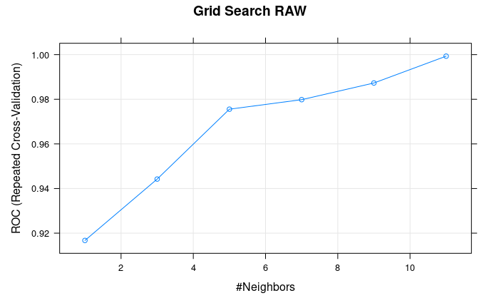

```r
#Execute model ("raw" data)
ctrl <- trainControl(
  method="repeatedcv",
  number=5,
  repeats = 3,
  classProbs=TRUE,
  summaryFunction = twoClassSummary
)

model.raw <- learn_model(trainData, ctrl, "RAW")
#We may decide to plot the results from the grid search of the model's parameters
plot(model.raw, main="Grid Search RAW")
```

```r
print(model.raw)
```

```
k-Nearest Neighbors

1794 samples
   2 predictor
   2 classes: 'positive', 'negative'

Pre-processing: centered (2), scaled (2)
Resampling: Cross-Validated (5 fold, repeated 3 times)
Summary of sample sizes: 1436, 1434, 1435, 1436, 1435, 1435, ...
Resampling results across tuning parameters:

  k   ROC        Sens       Spec
   1  0.9167365  0.8351852  0.9982879
   3  0.9442402  0.7861111  0.9992386
   5  0.9755631  0.7240741  1.0000000
   7  0.9798329  0.6833333  1.0000000
   9  0.9873061  0.6287037  1.0000000
  11  0.9993274  0.6212963  1.0000000

ROC was used to select the optimal model using the largest value.
The final value used for the model was k = 11.
```

```
Confusion Matrix and Statistics

          Reference
Prediction positive negative
  positive       10        0
  negative        3      583

               Accuracy : 0.995
                 95% CI : (0.9854, 0.999)
    No Information Rate : 0.9782
    P-Value [Acc > NIR] : 0.0009625

                  Kappa : 0.867

 Mcnemar's Test P-Value : 0.2482131

            Sensitivity : 0.76923
            Specificity : 1.00000
         Pos Pred Value : 1.00000
         Neg Pred Value : 0.99488
             Prevalence : 0.02181
         Detection Rate : 0.01678
   Detection Prevalence : 0.01678
      Balanced Accuracy : 0.88462

       'Positive' Class : positive
```

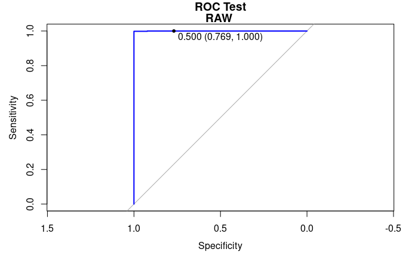

```r
cm.raw <- test_model(testData,model.raw,"RAW ")
```

Now, we include the preprocessing stage into the control method of *caret* and obtain new models. First with a simple undersampling technique. The use of *RUS* should obtain a training set that is perfectly balanced by removing instances from the majority class in a random way.

```
Confusion Matrix and Statistics

          Reference
Prediction positive negative
  positive       13      168
  negative        0      415

               Accuracy : 0.7181
                 95% CI : (0.6801, 0.7539)
    No Information Rate : 0.9782
    P-Value [Acc > NIR] : 1

                  Kappa : 0.0973

 Mcnemar's Test P-Value : <2e-16

            Sensitivity : 1.00000
            Specificity : 0.71184
         Pos Pred Value : 0.07182
         Neg Pred Value : 1.00000
             Prevalence : 0.02181
         Detection Rate : 0.02181
   Detection Prevalence : 0.30369
      Balanced Accuracy : 0.85592

       'Positive' Class : positive
```

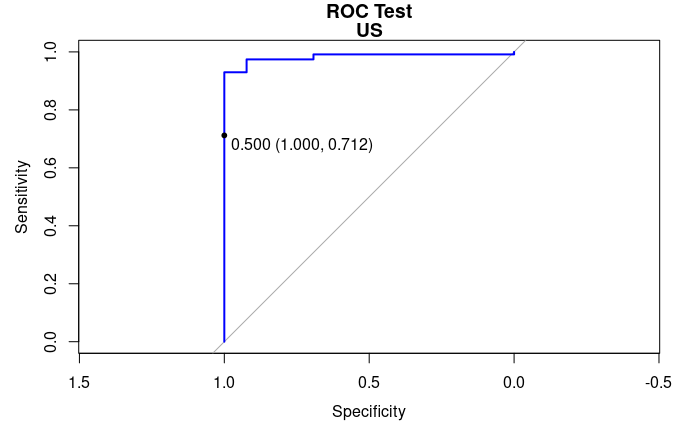

```r
#Execute model ("preprocessed" data)
#Undersampling
ctrl <- trainControl(method="repeatedcv", number=5, repeats = 3, classProbs=TRUE, summaryFunction = twoClassSummary, sampling = "down")

model.us <- learn_model(trainData, ctrl, "US")
cm.us <- test_model(testData, model.us, "US")
```

Now we must check the behavior of the random oversampling approach. The use of *ROS* should obtain a training set that is perfectly balanced by replicating instances from the minority class in a random way.

```
Confusion Matrix and Statistics

          Reference
Prediction positive negative
  positive       13       20
  negative        0      563

               Accuracy : 0.9664
                 95% CI : (0.9486, 0.9794)
    No Information Rate : 0.9782
    P-Value [Acc > NIR] : 0.9763

                  Kappa : 0.5512

 Mcnemar's Test P-Value : 2.152e-05

            Sensitivity : 1.00000
            Specificity : 0.96569
         Pos Pred Value : 0.39394
         Neg Pred Value : 1.00000
             Prevalence : 0.02181
         Detection Rate : 0.02181
   Detection Prevalence : 0.05537
      Balanced Accuracy : 0.98285

       'Positive' Class : positive
```

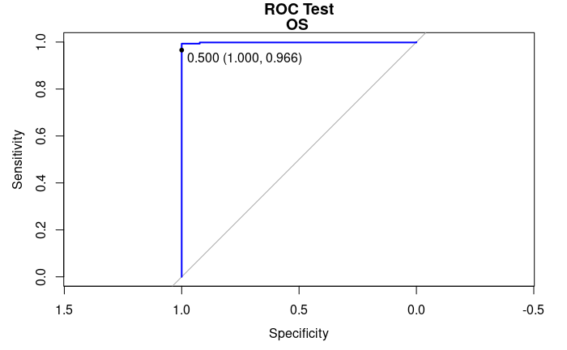

```r
#Oversampling
ctrl <- trainControl(method="repeatedcv", number=5, repeats = 3,
                     classProbs=TRUE, summaryFunction = twoClassSummary, sampling = "up")
model.os <- learn_model(trainData,ctrl,"OS ")
cm.os <- test_model(testData,model.os,"OS ")
```

Finally we test the SMOTE state-of-the-art solution. Applying SMOTE should obtain a perfectly balanced training set, creating new instances from the minority class.

```
Confusion Matrix and Statistics

          Reference
Prediction positive negative
  positive       13        6
  negative        0      577

               Accuracy : 0.9899
                 95% CI : (0.9782, 0.9963)
    No Information Rate : 0.9782
    P-Value [Acc > NIR] : 0.02474

                  Kappa : 0.8075

 Mcnemar's Test P-Value : 0.04123

            Sensitivity : 1.00000
            Specificity : 0.98971
         Pos Pred Value : 0.68421
         Neg Pred Value : 1.00000
             Prevalence : 0.02181
         Detection Rate : 0.02181
   Detection Prevalence : 0.03188
      Balanced Accuracy : 0.99485

       'Positive' Class : positive
```

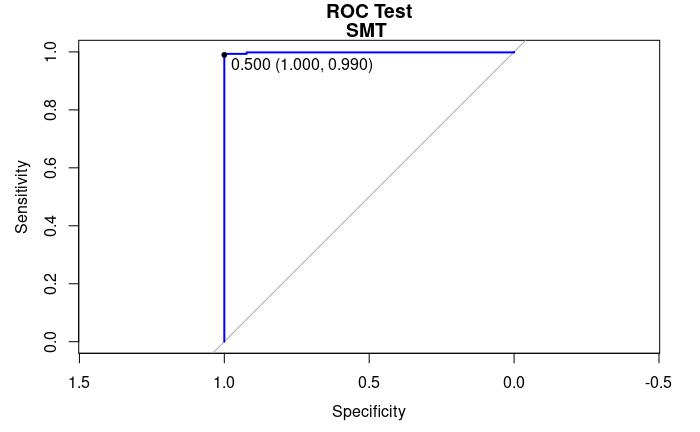

```r
#SMOTE
ctrl <- trainControl(method="repeatedcv", number=5, repeats = 3, classProbs=TRUE,summaryFunction = twoClassSummary, sampling = "smote")
model.smt <- learn_model(trainData,ctrl,"SMT ")
cm.smt <- test_model(testData,model.smt,"SMT ")
```

## Select Best Model

We now have 4 models learned from the same dataset but with different pre-processing options. Each model comprises a different accuracy estimation, and thus we need to compare the models to each other and select the most “accurate” in terms of imbalanced performance metrics, of course.

We can report on the performance of each model by first creating a list of the created models and using the summary function:

```r
# summarize accuracy of models

models <- list(raw = model.raw,us = model.us,os = model.os,smt = model.smt)
results <- resamples(models)
summary(results)
```

```
Call:
summary.resamples(object = results)

Models: raw, us, os, smt
Number of resamples: 15

ROC
         Min.   1st Qu.    Median      Mean   3rd Qu.      Max. NA's
raw 0.9968254 0.9991097 0.9996429 0.9993274 1.0000000 1.0000000    0
us  0.9588675 0.9870818 0.9922222 0.9886787 0.9942857 0.9996429    0
os  0.9939286 0.9975000 0.9979365 0.9982000 0.9998413 1.0000000    0
smt 0.9355357 0.9974642 0.9980952 0.9939463 0.9988109 1.0000000    0

Sens
         Min.   1st Qu.    Median      Mean 3rd Qu.  Max. NA's
raw 0.3333333 0.5000000 0.6666667 0.6212963    0.75 0.875    0
us  1.0000000 1.0000000 1.0000000 1.0000000    1.00 1.000    0
os  1.0000000 1.0000000 1.0000000 1.0000000    1.00 1.000    0
smt 0.8750000 0.8888889 1.0000000 0.9611111    1.00 1.000    0

Spec
         Min.   1st Qu.    Median      Mean   3rd Qu.      Max. NA's
raw 1.0000000 1.0000000 1.0000000 1.0000000 1.0000000 1.0000000    0
us  0.5641026 0.6890110 0.7200000 0.7079669 0.7400000 0.8085714    0
os  0.9628571 0.9771429 0.9800000 0.9779297 0.9814571 0.9857143    0
smt 0.9743590 0.9800285 0.9857143 0.9853491 0.9885714 0.9971510    0
```

The ideal procedure is to get a population of performance measures for each algorithm because each algorithm when evaluating several times (k fold cross validation).

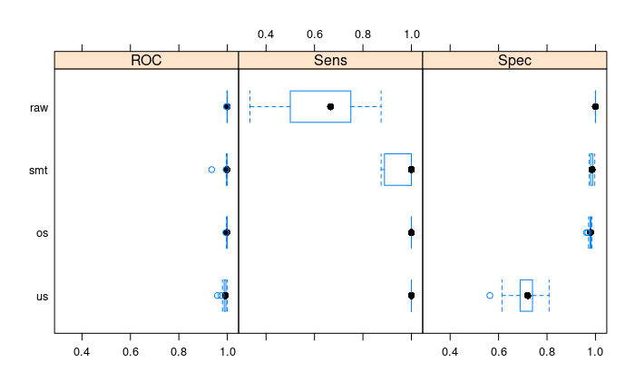

```r
# compare accuracy of models
bwplot(results)
```

```r
#dotplot(results)
```

We can finally make another different plot to compare additional metrics for imbalanced classification, such as precision, recall and F1.

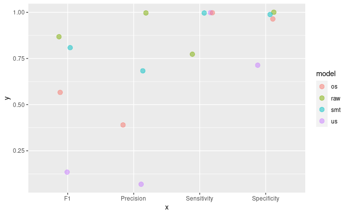

```r
#Carry out a comparison over all imbalanced metrics
comparison_metric <- function(models) {
  comparison <- data.frame(
    model = names(models),
    Sensitivity = rep(NA, length(models)),
    Specificity = rep(NA, length(models)),
    Precision = rep(NA, length(models)),
    F1 = rep(NA, length(models))
  )

  for (name in names(models)) {
    cm_model <- get(paste0("cm.", name))

    comparison[comparison$model == name, ] <- filter(comparison, model == name) %>% mutate(
      Sensitivity = cm_model$byClass["Sensitivity"],
      Specificity = cm_model$byClass["Specificity"],
      Precision = cm_model$byClass["Precision"],
      F1 = cm_model$byClass["F1"]
    )
  }

  comparison %>%
    gather(x, y, Sensitivity:F1) %>%
    ggplot(aes(x = x, y = y, color = model)) +
    geom_jitter(width = 0.2, alpha = 0.5, size = 3)
}

comparison_metric(models)
```

# Additional activities

The former tutorial served as a guide to understand the whole procedure to be carried out when addressing a classification problem that presents an uneven class distribution. Below, several tasks are proposed for extending this Rmd file to check whether all concepts have been acquired correctly.

## Activity 1: Extension with additional datasets. (mandatory)

Repeat the whole procedure carried out with “circle” data using now the subclus problem. Please be sure to avoid unnecesary operations / R code chunks.

```r
# load the CSV file from the local directory
subclus <- read.csv("data/subclus.csv", header=F)

# set the column names in the dataset
colnames(subclus) <- c("Attr1", "Attr2", "Class")
subclus$Class <- relevel(factor(subclus$Class), "positive")


# summarize statistical values
summary(subclus)
```

```
     Attr1            Attr2             Class
 Min.   :-84.00   Min.   :-282.0   positive:100
 1st Qu.: 65.75   1st Qu.: 155.8   negative:500
 Median :213.00   Median : 572.5
 Mean   :214.06   Mean   : 574.5
 3rd Qu.:365.50   3rd Qu.: 961.2
 Max.   :483.00   Max.   :1481.0
```

```r
imbalanceRatio(subclus)
```

```
[1] 0.2
```

```r
# Dataset scatter plot

subclus %>% ggvis(~Attr1, ~Attr2, fill = ~Class) %>% layer_points()
```

[output not shown]

```r
# Create split "data partitions":
set.seed(42) #To ensure the same output

#An easy way to create split "data partitions":
trainIndex <- createDataPartition(subclus$Class, p = .75,list = FALSE, times = 1)

trainData <- subclus[ trainIndex,]
testData  <- subclus[-trainIndex,]

#Check IR to ensure a stratified partition
imbalanceRatio(trainData)
```

```
[1] 0.2
```

```r
imbalanceRatio(testData)
```

```
[1] 0.2
```

```
Confusion Matrix and Statistics

          Reference
Prediction positive negative
  positive       18        7
  negative        7      118

               Accuracy : 0.9067
                 95% CI : (0.8484, 0.948)
    No Information Rate : 0.8333
    P-Value [Acc > NIR] : 0.007464

                  Kappa : 0.664

 Mcnemar's Test P-Value : 1.000000

            Sensitivity : 0.7200
            Specificity : 0.9440
         Pos Pred Value : 0.7200
         Neg Pred Value : 0.9440
             Prevalence : 0.1667
         Detection Rate : 0.1200
   Detection Prevalence : 0.1667
      Balanced Accuracy : 0.8320

       'Positive' Class : positive
```

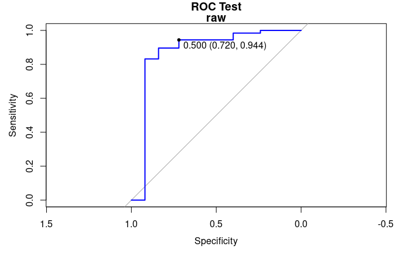

```r
model.raw <- learn_model(
  trainData,
  trainControl(
    method="repeatedcv",
    number=5,
    repeats = 3,
    classProbs=TRUE,
    summaryFunction = twoClassSummary,
  ),
  "raw"
)
cm.raw <- test_model(testData, model.raw, "raw")
```

```
Confusion Matrix and Statistics

          Reference
Prediction positive negative
  positive       23       26
  negative        2       99

               Accuracy : 0.8133
                 95% CI : (0.7416, 0.8722)
    No Information Rate : 0.8333
    P-Value [Acc > NIR] : 0.7814

                  Kappa : 0.5145

 Mcnemar's Test P-Value : 1.383e-05

            Sensitivity : 0.9200
            Specificity : 0.7920
         Pos Pred Value : 0.4694
         Neg Pred Value : 0.9802
             Prevalence : 0.1667
         Detection Rate : 0.1533
   Detection Prevalence : 0.3267
      Balanced Accuracy : 0.8560

       'Positive' Class : positive
```

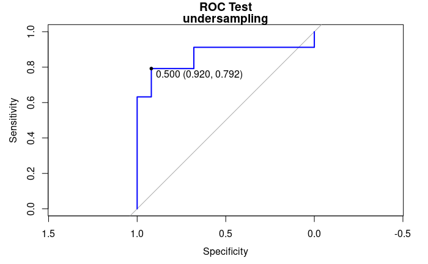

```r
model.undersampling <- learn_model(
  trainData,
  trainControl(
    method="repeatedcv",
    number=5,
    repeats = 3,
    classProbs=TRUE,
    summaryFunction = twoClassSummary,
    sampling = "down"
  ),
  "undersampling"
)
cm.undersampling <- test_model(testData, model.undersampling, "undersampling")
```

```
Confusion Matrix and Statistics

          Reference
Prediction positive negative
  positive       24       24
  negative        1      101

               Accuracy : 0.8333
                 95% CI : (0.7639, 0.8891)
    No Information Rate : 0.8333
    P-Value [Acc > NIR] : 0.5531

                  Kappa : 0.5614

 Mcnemar's Test P-Value : 1.083e-05

            Sensitivity : 0.9600
            Specificity : 0.8080
         Pos Pred Value : 0.5000
         Neg Pred Value : 0.9902
             Prevalence : 0.1667
         Detection Rate : 0.1600
   Detection Prevalence : 0.3200
      Balanced Accuracy : 0.8840

       'Positive' Class : positive
```

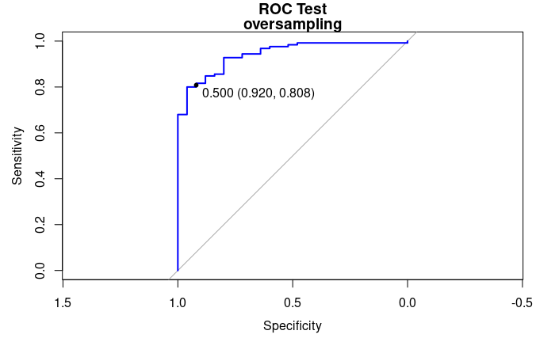

```r
model.oversampling <- learn_model(
  trainData,
  trainControl(
    method="repeatedcv",
    number=5,
    repeats = 3,
    classProbs=TRUE,
    summaryFunction = twoClassSummary,
    sampling = "up"
  ),
  "oversampling"
)
cm.oversampling <- test_model(testData, model.oversampling, "oversampling")
```

```
Confusion Matrix and Statistics

          Reference
Prediction positive negative
  positive       22       15
  negative        3      110

               Accuracy : 0.88
                 95% CI : (0.817, 0.9273)
    No Information Rate : 0.8333
    P-Value [Acc > NIR] : 0.072978

                  Kappa : 0.6376

 Mcnemar's Test P-Value : 0.009522

            Sensitivity : 0.8800
            Specificity : 0.8800
         Pos Pred Value : 0.5946
         Neg Pred Value : 0.9735
             Prevalence : 0.1667
         Detection Rate : 0.1467
   Detection Prevalence : 0.2467
      Balanced Accuracy : 0.8800

       'Positive' Class : positive
```

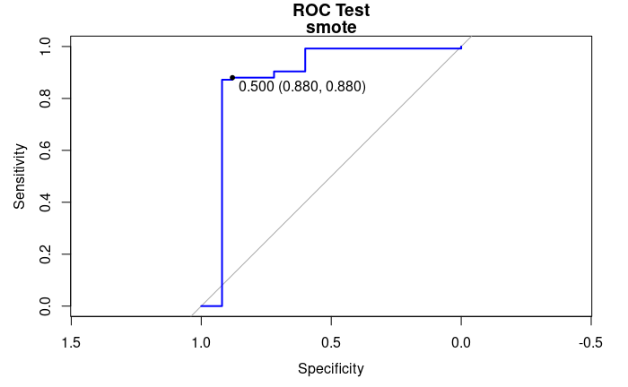

```r
model.smote <- learn_model(
  trainData,
  trainControl(
    method="repeatedcv",
    number=5,
    repeats = 3,
    classProbs=TRUE,
    summaryFunction = twoClassSummary,
    sampling = "smote"
  ),
  "smote"
)
cm.smote <- test_model(testData, model.smote, "smote")
```

```r
# Summarize performance of models

models <- list(
  raw = model.raw,
  undersampling = model.undersampling,
  oversampling = model.oversampling,
  smote = model.smote
)
results <- resamples(models)
summary(results)
```

```
Call:
summary.resamples(object = results)

Models: raw, undersampling, oversampling, smote
Number of resamples: 15

ROC
                   Min.   1st Qu.    Median      Mean   3rd Qu.      Max. NA's
raw           0.9151111 0.9373333 0.9417778 0.9497185 0.9613333 0.9942222    0
undersampling 0.8973333 0.9120000 0.9280000 0.9271407 0.9371111 0.9600000    0
oversampling  0.8822222 0.9462222 0.9551111 0.9512296 0.9664444 0.9782222    0
smote         0.9204444 0.9426667 0.9746667 0.9642074 0.9813333 0.9884444    0

Sens
                   Min.   1st Qu.    Median      Mean   3rd Qu.      Max. NA's
raw           0.4000000 0.6000000 0.6666667 0.6755556 0.7666667 0.9333333    0
undersampling 0.8000000 0.9333333 1.0000000 0.9511111 1.0000000 1.0000000    0
oversampling  0.9333333 0.9333333 1.0000000 0.9733333 1.0000000 1.0000000    0
smote         0.6666667 0.8666667 0.9333333 0.9022222 0.9666667 1.0000000    0

Spec
                   Min.   1st Qu.    Median      Mean   3rd Qu.      Max. NA's
raw           0.9066667 0.9466667 0.9600000 0.9564444 0.9733333 1.0000000    0
undersampling 0.7466667 0.7733333 0.8000000 0.8017778 0.8333333 0.8666667    0
oversampling  0.7333333 0.7800000 0.8000000 0.7946667 0.8266667 0.8400000    0
smote         0.8400000 0.8800000 0.9066667 0.9048889 0.9266667 0.9733333    0
```

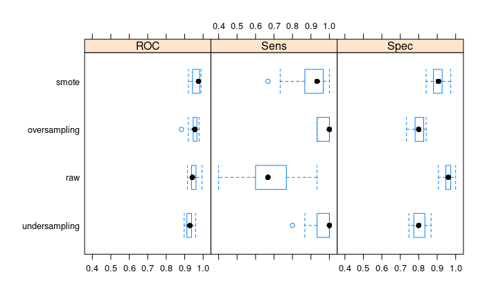

```r
# Carry out a visual comparison over all imbalanced metrics
bwplot(results)
```

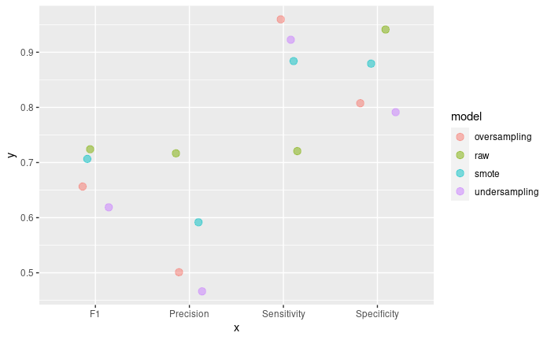

```r
comparison_metric(models)
```

*Si nos fijamos en los diagramas de cajas, que muestran las métricas ROC, Sensibilidad y Especificidad y cuyo conjunto de resultados se han obtenido con los diferentes folds y la técnicas de balanceo, se puede observar que el modelo básico “raw” tiene bastantes problemas en clasificar las instancias de la clase minoritaria (sensibilidad) mientras que clasifica bastante bien los ejemplos de la clase mayoritaria (especificidad).*

*Por último, la aplicación de SMOTE hace que mejore la capacidad de clasificar las instancias de la clase minoritaria respecto al modelo original y además consigue que el trade-off entre sensibilidad y especificidad no sea perjudicial para este último. De hecho, consigue tener una especificidad muy similar al del modelo base. Lo único que habría que destacar sobre la aplicación de SMOTE es que la métrica sensibilidad presenta una distancia intercuartil bastante considerable, y por lo tanto una gran dispersión entre los resultados, cosa que no ocurre con undersampling y oversampling.*

*Ahora nos fijamos en la gráfica en la que se muestran las métricas F1, Precisión, Sensibilidad y Especificidad. Se tiene que indicar que F1 es una métrica que se calcula utilizando la precisión y la sensibilidad (también llamada recall), y también que la precisión se calcula como el ratio entre aquellos que son verdaderamente de la clase positiva y la suma de los que ha considerado el modelo como de la clase positiva.*

*En esta gráfica se puede observar que el modelo base (sin aplicarle ninguna técnica de balanceo) predomina con la mejor métrica en F1, precisión y especificidad. Como el objetivo de las técnicas de balanceo es hacer que el modelo clasifique mejor la clase minoritaria, y que por lo tanto, clasifique las dos clases de la manera correcta, habría que ver aquellos que tienen una métrica buena en sensiblidad y especificidad, y en el que el trade-off sea favorable para los dos. Como se ha comentado en la gráfica anterior, el método que conseguía esto era SMOTE.*

*En el caso en el que no nos importe clasificar algunas instancias negativas (las que son cercanas al “cluster” de instancias positivas o están dentro de ese cluster) y clasificar mejor las instancias de la clase minoritaria, el mejor modelo a considerar es aquel en el que se aplica SMOTE.*

## Activity 2: Using the “imbalance” library (mandatory)

As we have commented, there exists a CRAN package named as “imbalance” that implements some of the most well-known data preprocesing techniques for imbalanced classification. We must take a closer look to the documentation in both the [imbalance package homepage](https://github.com/ncordon/imbalance). or the help function By using the “imbalance” library we may consider the application of advanced techniques based on SMOTE. For that purpose, we must focus on the “oversample” function.

It is your turn to select up to four different SMOTE techniques and apply them over some of the datasets provided by the package (ecoli1, glass0, haberman or yeast4, for example). Are there any significant differences among the results?

```r
# Load the data
imbalanceRatio(glassDataset)
```

```
[1] 0.4861111
```

```r
# Apply preprocessing with oversample function
glassDataset.smote <- imbalance::oversample(
  glassDataset,
  method="SMOTE",
  ratio = .8
)

glassDataset.mwmote <- imbalance::oversample(
  glassDataset,
  method="MWMOTE",
  ratio = .8
)

glassDataset.blsmote <- imbalance::oversample(
  glassDataset,
  method="BLSMOTE",
  ratio = .8
)
```

```
[1] "Borderline-SMOTE done"
```

```r
glassDataset.dbsmote <- imbalance::oversample(
  glassDataset,
  method="DBSMOTE",
  ratio = .8
)
```

[output not shown]

[output cut: 49 more lines]

```r
# Check results with kNN, DT or any other classifier

trainControlGlass <- trainControl(
  classProbs = T,
  summaryFunction = twoClassSummary,
  method="repeatedcv",
  number=5,
  repeats = 3,
)

model.smote.glass <- train(
  Class ~ .,
  data = glassDataset.smote,
  method = "knn",
  trControl = trainControlGlass,
  preProcess = c("center","scale"),
  metric="ROC",
  tuneGrid = expand.grid(k = c(1,3,5,7,9,11))
)

model.mwmote.glass <- train(
  Class ~ .,
  data = glassDataset.mwmote,
  method = "knn",
  trControl = trainControlGlass,
  preProcess = c("center","scale"),
  metric="ROC",
  tuneGrid = expand.grid(k = c(1,3,5,7,9,11))
)

model.blsmote.glass <- train(
  Class ~ .,
  data = glassDataset.blsmote,
  method = "knn",
  trControl = trainControlGlass,
  preProcess = c("center","scale"),
  metric="ROC",
  tuneGrid = expand.grid(k = c(1,3,5,7,9,11))
)

model.dbsmote.glass <- train(
  Class ~ .,
  data = glassDataset.dbsmote,
  method = "knn",
  trControl = trainControlGlass,
  preProcess = c("center","scale"),
  metric="ROC",
  tuneGrid = expand.grid(k = c(1,3,5,7,9,11))
)

smote.results <- data.frame(
  smote = model.smote.glass$results$ROC,
  mwmote = model.mwmote.glass$results$ROC,
  blsmote = model.blsmote.glass$results$ROC,
  dbsmote = model.dbsmote.glass$results$ROC
)

friedman.result <- friedman.test(as.matrix(smote.results))
friedman.result
```

```
    Friedman rank sum test

data:  as.matrix(smote.results)
Friedman chi-squared = 5, df = 3, p-value = 0.1718
```

```r
groups <- rep(1:dim(smote.results)[2], each=dim(smote.results)[1])
post.hoc <- pairwise.wilcox.test(
  as.matrix(smote.results),
  groups,
  p.adjust = "holm",
  paired = T
)
post.hoc
```

```
    Pairwise comparisons using Wilcoxon signed rank exact test

data:  as.matrix(smote.results) and groups

  1    2    3
2 1.00 -    -
3 0.78 1.00 -
4 0.38 0.78 1.00

P value adjustment method: holm
```

Now, make a plot comparison between the original and preprocessed dataset (only for SMOTE, for example). Recall that, being a 2D plot, you must only two of the input columns. Alternatively, you can carry out a “tsne” prior to the plot.

```r
# PCA
originaldataset.model.pca <- prcomp(~.-Class, data=glassDataset, rank. = 2)
smotedataset.model.pca <- prcomp(~.-Class, data=glassDataset.smote, rank. = 2)

original.pca.dataset <- data.frame(
  predict(originaldataset.model.pca, newdata = glassDataset)
)
original.pca.dataset$Class <- glassDataset$Class

smote.pca.dataset <- data.frame(
  predict(smotedataset.model.pca, newdata = glassDataset.smote)
)
smote.pca.dataset$Class <- glassDataset.smote$Class

# Visualize the data distribution between original and preprocess data.
# Original dataset
original.pca.dataset %>% ggvis(~PC1, ~PC2, fill = ~Class) %>% layer_points()
```

[output not shown]

```r
# Dataset after smote
smote.pca.dataset %>% ggvis(~PC1, ~PC2, fill = ~Class) %>% layer_points()
```

[output not shown]

## Activity 3: Analyze the behavior of SMOTE preprocessing (optional)

In this last part of the practice, we intend to analyse the influence of the different parameters of SMOTE. In fact, during the theoretical classes, it was indicated that many of the SMOTE parameters could have a certain importance in terms of the quality of the new synthetic examples generated on the training set.

Therefore, the objective of this task is to contrast some of them to see which ones can have more influence, or which ones can be significant values to observe differences in the results.

To carry out this activity, the first issue is to determine the experimental framework. As for the datasets to be used, “subclus” and “circle” can be selected by default, although the study will be more relevant when the number of problems, both synthetic and real, is greater. In any case, the student should use a cross validation technique to check the results.

As a base classifier to analyze the behavior, the student may use by default kNN with K = 1 or K = 3. It could also be interesting to analyze the results with the C4.5 decision tree or even Random Forest or any other quality technique that the student consider to be appropriate.

Finally, it would remain to be discussed which parameters are appropriate for the study, and what range of values to use. The most direct parameters would be K for the number of neighbors chosen (for example, between K = 1, K = 5, K = N/2 with N number of positive instances, etc.), and the percentage of oversampling (double the minority class, 50-50 class ratio, 50% minority over majority class, among others).

To do so, you can either perform an ad hoc implementation of SMOTE, or analyze among those available in the different R packages, the one that allows you to perform a “Racing” of the parameters (clue: check the current available imbalanced packages in CRAN).

Build the corresponding tables of results and make a brief analysis if any interesting patterns are observed during the experimental analysis.

# Final Comments

Hope you enjoyed this tutorial about Imbalanced Classification in Machine Learning. If you need further details on how to perform any kind of task, please ask me via email at alberto@decsai.ugr.es